# Chilko data

K. Davidson

November 20, 2020

## Data summary

DFO StAD has collected a variety of data pertaining to juvenile and adult sockeye at Chilko over the course of time (Figure 1), including:

- Smolt abundance at migration
- Smolt length at migration
- Smolt age at migration
- Smolt migration timing (daily totals) - this may exist at finer resolution too
- Fry abundance, age, and size (sparse data)
- Total adult spawner abundance
- Effective female spawner abundance
- Male and female spawner length
- Fecundity
- Adult age (total and freshwater)
- Water level

Smolt length and age and fry length and age are currently stored in data formats that would require considerable work to bring into a useable format, especially for historical data.

Other types of data that may be held elsewhere:

- Smolt freshwater growth rate (otoliths, scales or captures?)
- Smolt weight
- Smolt fat score
- Smolt growth rate (otoliths, scales or repeated measures)
  - Smolt fork length in Lower Fraser/SoG
- Smolt survival during migration
  - Smolt abundance in Lower Fraser/SoG
- Smolt misc physiology - swim performance, hormones, respirometry, etc.
- Total growth rate over life (otoliths, scales) - PSC does not record to this level for adults but possible it could be obtained
- Adult fat score
- Adult misc physiology - swim performance, hormones, respirometry, etc.
- Fry abundance
- Lake productivity/food availability (especially during fertilization experimental years) - likely patchy at best
- Predator abundance (proxy or estimate of mortality rate)

Other data sources might be accessed through Environmental Watch Program, Hinch Lab, Mission Downstream (Tadey) or Strait of Georgia (Neville) programs.

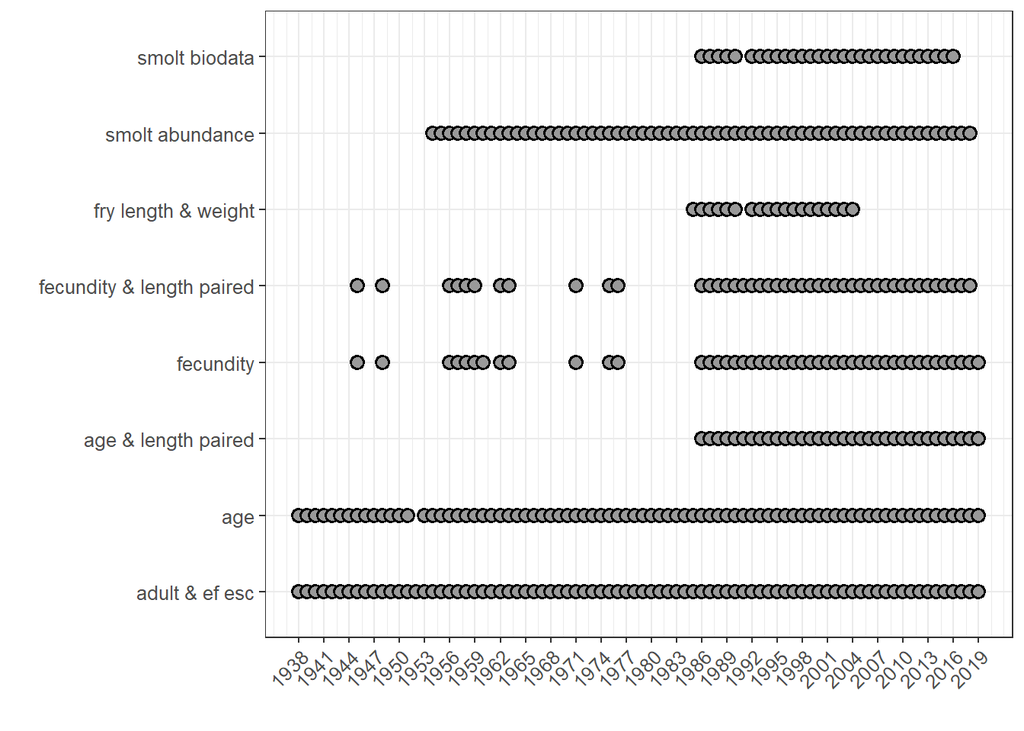

Figure 1. DFO Stock assessment time series for Chilko data types. No sex information was collected in conjunction with 'age' data in 1952 hence the gap.